# simon-5502-03-demo

## Part 1. Read the data and produce descriptive statistics

## File details

This program was written by Steve Simon on 2025-01-30 and is placed in the public domain. You can use this program any way you please.

This program reads [albuquerqe-housing.csv](https://github.com/pmean/data/blob/main/files/albuquerque-housing.csv),a dataset that examines sales prices for residential homes in 1993 in Albuquerque, New Mexico. Refer to the [data dictionary](https://github.com/pmean/data/blob/main/files/albuquerque-housing.yaml) for a more detailed description.

```r
library(broom)
library(glue)
library(knitr)
library(tidyverse)
R.version.string
```

```
[1] "R version 4.5.0 (2025-04-11 ucrt)"
```

```r
Sys.Date()
```

```
[1] "2026-02-03"
```

## Intermediate files

- alb: original data from albuquerque-housing.csv
- m1: traditional t-test comparing prices by custom-built
- m2: linear model comparing prices by custom-built
- m3: linear model adjusting for sqft
- alb1: small tibble for future predictions of m2
- alb2: small tibble for unadjusted future predictions of m3
- alb3: small tibble for adjusted future predictions of m3
- r3: residuals and predicted values for m3
- plot1: boxplot of custom_build and price
- plot2: plot of predicted versus residuals
- plot3: qq plot of residuals

## Read the data

```r
alb <- read_csv(
  file="../data/albuquerque-housing.csv",
  col_names=TRUE,
  col_types="nnnnccc",
  na=".")
glimpse(alb)
```

```
Rows: 117
Columns: 7
$ price        <dbl> 205000, 208000, 215000, 215000, 199900, 190000, 180000, 1…
$ sqft         <dbl> 2650, 2600, 2664, 2921, 2580, 2580, 2774, 1920, 2150, 171…
$ age          <dbl> 13, NA, 6, 3, 4, 4, 2, 1, NA, 1, 4, 8, 15, 14, 18, NA, 16…
$ features     <dbl> 7, 4, 5, 6, 4, 4, 4, 5, 4, 3, 5, 6, 3, 5, 8, 3, 4, 3, 4, …
$ northeast    <chr> "yes", "yes", "yes", "yes", "yes", "yes", "yes", "yes", "…
$ custom_build <chr> "yes", "yes", "yes", "yes", "yes", "no", "no", "yes", "no…
$ corner_lot   <chr> "no", "no", "no", "no", "no", "no", "no", "no", "no", "no…
```

#### Comments on the code

You have seen the read-csv function before. The na=“.” argument tells R that missing values are designated by a single dot. Normally, R expects missing values to be designated by NA.

## Descriptive statistics for price

```r
alb |>
  summarize(
    price_mean=mean(price),
    price_sd=sd(price),
    price_min=min(price),
    price_max=max(price))
```

```
# A tibble: 1 × 4
  price_mean price_sd price_min price_max
       <dbl>    <dbl>     <dbl>     <dbl>
1    106274.   38044.     54000    215000
```

#### Comment on the code

I use the word “dollars” in the interpretation below rather than putting in a dollar sign ($) because if Quarto sees two of these in a single line of comments, it will try to produce a math equation. You can work around this by preceding the dollar sign with a backslash ($). This backslash trick also works in your comments for other symbols that Quarto might get confused by, such as the asterisk or the square bracket symbols.

#### Interpretation of the output

The average house sold for 106 thousand dollars. The range of prices is large, going from 54 thousand dollars to 215 thousand dollars. All of these prices seem low, but perhaps those prices were quite normal back in 1993.

## Descriptive statistics for sqft

```r
alb |>
  summarize(
    sqft_mean=mean(sqft),
    sqft_sd=sd(sqft),
    sqft_min=min(sqft),
    sqft_max=max(sqft))
```

```
# A tibble: 1 × 4
  sqft_mean sqft_sd sqft_min sqft_max
      <dbl>   <dbl>    <dbl>    <dbl>
1     1654.    524.      837     3750
```

#### Interpretation of the output

The average house is 1,600 square feet. The range again is quite wide. The houses seems small; the largest is still less than 4,000 square feet. This may have been reasonable back in 1993.

## Descriptive statistics for custom_build

```r
alb |>
    count(custom_build) |>
    mutate(total=sum(n)) |>
    mutate(pct=round(100*n/total)) |>
    mutate(pct=glue("{pct}% ({n}/{total})")) |>
    select(-n, -total)
```

```
# A tibble: 2 × 2
  custom_build pct
  <chr>        <glue>
1 no           77% (90/117)
2 yes          23% (27/117)
```

#### Interpretation of the output

Only about a quarter of the houses are custom-built.

## Part 2. t-test, traditional and with lm

## Boxplot comparing price by custom_build.

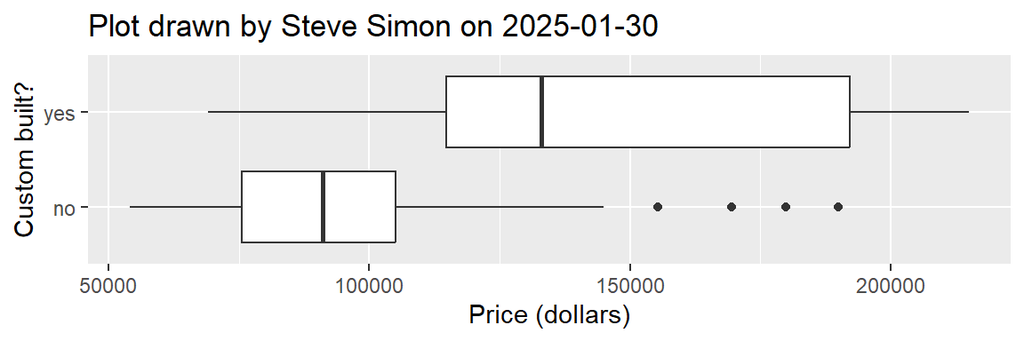

```r
alb |>
    ggplot() +
      aes(x=custom_build, y=price) +
      geom_boxplot() +
      xlab("Custom built?") +
      ylab("Price (dollars)") +
      coord_flip() +
      ggtitle("Plot drawn by Steve Simon on 2025-01-30") -> plot_1
plot_1
```

#### Interpretation of the output

Prices are substantially higher for custom-built homes.

## Mean price by custom_build

```r
alb |>
    group_by(custom_build) |>
    summarize(
        mean_price=mean(price),
        sd_price=sd(price),
        n=n()) -> table_1
```

## The traditional form of the t-test

```r
m1 <- t.test(
    alb$price[alb$custom_build=="yes"],
    alb$price[alb$custom_build=="no"],
    var.equal=TRUE)
m1
```

```
    Two Sample t-test

data:  alb$price[alb$custom_build == "yes"] and alb$price[alb$custom_build == "no"]
t = 7.1602, df = 115, p-value = 8.159e-11
alternative hypothesis: true difference in means is not equal to 0
95 percent confidence interval:
 36114.14 63736.98
sample estimates:
mean of x mean of y
144677.78  94752.22
```

#### Comment on the code

The [t.test](https://stat.ethz.ch/R-manual/R-devel/library/stats/html/t.test.html) function will test the hypothesis that the mean is the same in both groups. It requires a bit of awkward syntax, so I prefer to do a comparable test using the lm function.

#### Interpretation of the output

The t statistic (7.2) is large, the p-value is very small (< 0.001), and the confidence interval (36 to 64 thousand dollars) excludes the value of zero. You should reject the null hypothesis and conclude that the average price of custom built homes is higher than the average price of regular homes.

## Using lm to conduct a t-test

```r
m2 <- lm(price~custom_build, data=alb)
tidy(m2) |>
  mutate(
    p.value =
      case_when(
        p.value <  0.001 ~ "< 0.001",
        p.value >= 0.001 ~ as.character(round(p.value, 3))))
```

```
# A tibble: 2 × 5
  term            estimate std.error statistic p.value
  <chr>              <dbl>     <dbl>     <dbl> <chr>
1 (Intercept)       94752.     3350.     28.3  < 0.001
2 custom_buildyes   49926.     6973.      7.16 < 0.001
```

#### Interpretation of the output

The intercept, 95 thousand dollars, is the estimated average price when the indicator variable equals zero. R sets up the indicator variable with 1 for the category that appears last alphabetically.

The slope, 50 thousand dollars, is the estimated average change in price for a custom-built home compared to a regular home. The t-statistic (7.2) and the p-value match the values computed using the t.test function. Your conclusion, that the average price of custom built homes is higher than that of normal homes remains the same.

## Confidence intervals

```r
m2 |>
    confint() |>
    round(digits=-3)
```

```
                2.5 % 97.5 %
(Intercept)     88000 101000
custom_buildyes 36000  64000
```

#### Comment on the code

The [confint](https://stat.ethz.ch/R-manual/R-devel/library/stats/html/confint.html) function (part of base R) calculates confidence intervals for the estimates produces by the lm function as well as some other data analysis functions in R.

Note that I used the round function here with digits=-3 to round to the nearest thousand dollars. This is optional, but encouraged. What is required, however, is that you always round your data aggressively in your interpretation of the output.

#### Interpretation of the output

Even after allowing for sampling error, the difference in means is at least 36 thousand dollars and possibly as much as 64 thousand dollars.

## Using the predict function

```r
alb_1 <- tibble(custom_build=c("no", "yes"))
augment(m2, newdata=alb_1)
```

```
# A tibble: 2 × 2
  custom_build .fitted
  <chr>          <dbl>
1 no            94752.
2 yes          144678.
```

#### Comments on the code

You have already seen how the augment function (part of the broom package) can produce predicted values and residuals for the values in the dataset. You can also use augment to make future predictions. Just specify a data frame or tibble with the future values of the independent variable(s) that you want to predict at.

#### Interpretation of the output

The prediction for a future observation of a normal (not custom-built) home is 95 thousand dollars. The prediction for a custom-built house is 145 thousand dollars.

## Part 3. Analysis of covariance

Note: the size of the home might be associated both with custom build and price. Let’s investigate.

## Boxplot of sqft by custom_build

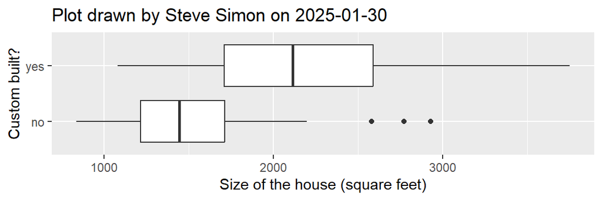

```r
alb |>
    ggplot() +
      aes(x=custom_build, y=sqft) +
      geom_boxplot() +
      xlab("Custom built?") +
      ylab("Size of the house (square feet)") +
      coord_flip() +
      ggtitle("Plot drawn by Steve Simon on 2025-01-30")
```

#### Interpretation of the output

Custom-built homes tend to be much larger.

## Mean sqft by custom_build

```r
alb |>
    group_by(custom_build) |>
    summarize(
        mean_sqft=mean(sqft),
        sd_sqft=sd(sqft),
        n=n())
```

```
# A tibble: 2 × 4
  custom_build mean_sqft sd_sqft     n
  <chr>            <dbl>   <dbl> <int>
1 no               1505.    393.    90
2 yes              2149.    603.    27
```

#### Interpretation of the output

The average size of regular homes is about 1,500 square feet. Custom-built homes are about 650 square feet larger on average.

## Scatterplot of sqft and price

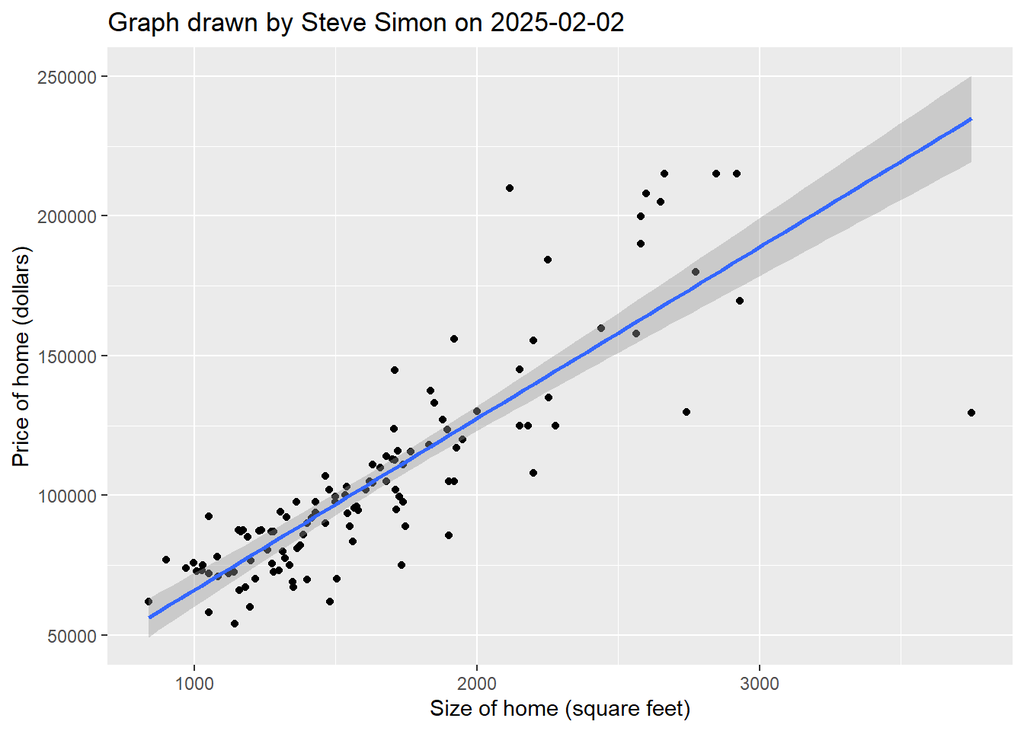

```r
alb |>
  ggplot() +
    aes(x=sqft, y=price) +
    geom_point() +
    geom_smooth(method="lm") +
    xlab("Size of home (square feet)") +
    ylab("Price of home (dollars)") +
    ggtitle("Graph drawn by Steve Simon on 2025-02-02")
```

#### Interpretation of the output

There is a strong positive relationship. Larger homes tend to sell for more money.

## Analysis of covariance model

```r
m3 <- lm(price ~ custom_build + sqft, data=alb)

m3 |>
  tidy() |>
  mutate(
    p.value =
      case_when(
        p.value <  0.001 ~ "< 0.001",
        p.value >= 0.001 ~ as.character(round(p.value, 3))))
```

```
# A tibble: 3 × 5
  term            estimate std.error statistic p.value
  <chr>              <dbl>     <dbl>     <dbl> <chr>
1 (Intercept)      11413.    6550.        1.74 0.084
2 custom_buildyes  14286.    5103.        2.80 0.006
3 sqft                55.4      4.12     13.4  < 0.001
```

## Prediction without adjustment

```r
alb |>
  group_by(custom_build) |>
  summarize(sqft=mean(sqft)) -> alb_2
alb_2
```

```
# A tibble: 2 × 2
  custom_build  sqft
  <chr>        <dbl>
1 no           1505.
2 yes          2149.
```

#### Comment on the code

To make an unadjusted prediction in the analysis of covariance model, you need to specify the two values for custom_build (“no” and “yes”) along with the average sqft within each value of custom_build. This makes the “apples-to-oranges” nature of the unadjusted comparison more obvious.

```r
augment(m3, newdata=alb_2)
```

```
# A tibble: 2 × 3
  custom_build  sqft .fitted
  <chr>        <dbl>   <dbl>
1 no           1505.  94752.
2 yes          2149. 144678.
```

#### Interpretation of the output

The predicted future value for a normal house with 1,500 square feet (the average size for normal houses) is 95 thousand dollars. The predicted future value for a custom-built house with 2,150 square feet (the average size for custom-built houses) is 145 thousand dollars. This matches the predicted future values from the model that did not include sqft as a covariate.

## Prediction with adjustment

```r
alb_2 |>
  mutate(sqft=mean(alb$sqft)) -> alb_3
alb_3
```

```
# A tibble: 2 × 2
  custom_build  sqft
  <chr>        <dbl>
1 no           1654.
2 yes          1654.
```

#### Comment on the code

To make an adjusted prediction, you replace the different mean square footage values by a single mean of all the data.

```r
augment(m3, newdata=alb_3)
```

```
# A tibble: 2 × 3
  custom_build  sqft .fitted
  <chr>        <dbl>   <dbl>
1 no           1654. 102977.
2 yes          1654. 117263.
```

#### Interpretation of the output

The predicted future price of a normal house with a size of 1,650 square feet is 103 thousand dollars. The predicted future price of a custom-built house with a size of 1,650 square feet is 117 thousand dollars. The difference, 14 thousand dollars, matches the estimate from the analysis of covariance model.

## Part 4. Checking your assumptions

## Compute residuals and predicted values

```r
r3 <- augment(m3)
```

## Plot predicted values versus residuals

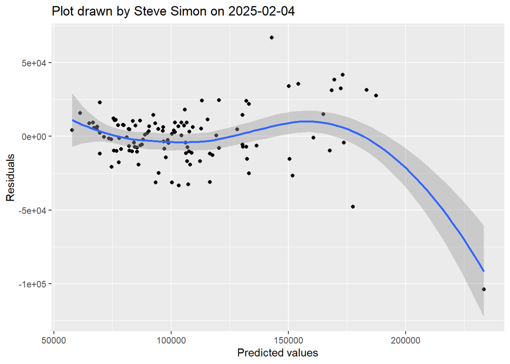

```r
r3 |>
    ggplot() +
    aes(x=.fitted, y=.resid) +
    geom_point() +
    geom_smooth(method="loess") +
    xlab("Predicted values") +
    ylab("Residuals") +
    ggtitle("Plot drawn by Steve Simon on 2025-02-04") -> plot_2
plot_2
```

#### Interpretation of the output

There appears to be an outlier: the largest predicted value also has the smallest residual. Other than that, there is no evidence of violation of assumptions. There is no evidence of heterogeneity or of nonlinearity beside the outlier.

## Normal probability plot

```r
r3 |>
    ggplot() +
    aes(sample=.resid) +
    stat_qq() +
    ggtitle("Plot drawn by Steve Simon on 2025-02-04") -> plot_3
```

## Examine studentized deleted residuals

```r
r3 |>
    filter(abs(.std.resid) > 3) |>
    select(price, custom_build, sqft, .std.resid)
```

```
# A tibble: 2 × 4
   price custom_build  sqft .std.resid
   <dbl> <chr>        <dbl>      <dbl>
1 129500 yes           3750      -5.66
2 210000 yes           2116       3.45
```

#### Interpretation of the output

It is always tricky to identify what makes a data point an outlier. Here it is not quite so difficult.

There are two outliers in the residuals. The first is a very big house that did not sell for very much money. The second is a very expensive house that was not very big. Both were custom-built.

## Examine leverage

```r
p <- 3
n <- nrow(alb)
r3 |>
    filter(.hat > 3*(p+1)/n) |>
    select(price, custom_build, sqft, .hat)
```

```
# A tibble: 1 × 4
   price custom_build  sqft  .hat
   <dbl> <chr>        <dbl> <dbl>
1 129500 yes           3750 0.147
```

#### Interpretation of the output

The house with the largest square footage is an influential data point.

## Examine Cook’s distance

```r
r3 |>
    filter(.cooksd > 1) |>
    select(price, custom_build, sqft, .cooksd)
```

```
# A tibble: 1 × 4
   price custom_build  sqft .cooksd
   <dbl> <chr>        <dbl>   <dbl>
1 129500 yes           3750    1.85
```

#### Interpretation of the output

The largest house has a strong influence on the regression equation.

## Save everything

```r
save(
  alb,
  m1,
  m2,
  m3,
  alb_1,
  alb_2,
  alb_3,
  r3,
  plot_1,
  plot_2,
  plot_3,
  table_1,
  file="../data/module03.RData")
```